# demographics_of_money

Matt Biggs

## As the wealth of a nation increases, demographics change

Over time, the world has become wealthier. Some nations experienced greater financial growth than others over the last half-century. As Gross Domestic Product (GDP) in a country increases, two major trends occur: first, birth rate decreases, and second (as a natural consequence), the average age of the population increases. The average trend over time is indicated as a thick, black line.

[GDP](https://data.worldbank.org/indicator/NY.GDP.MKTP.CD), [birth rate](https://data.worldbank.org/indicator/sp.dyn.cbrt.in), and [aging population](https://data.worldbank.org/indicator/SP.POP.65UP.TO.ZS) datasets are all made available by the World Bank.

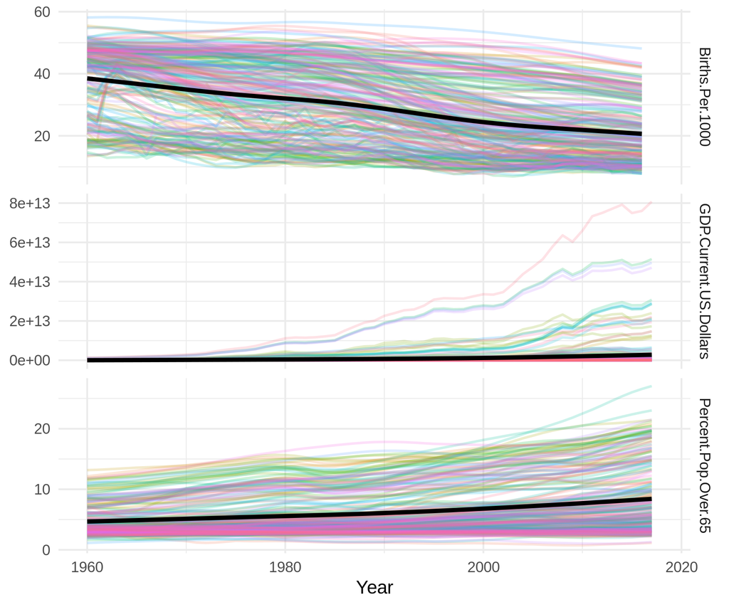

## Most of the world economies grew predictably, but there are outliers

From 1960-2017, the average national GDP (across the globe) grew 10,000 times larger. Of course, there was a distribution around that average. The distribution appears bell-shaped when GDP is displayed on a log-scale. On the plot below, the average is indicated, as are three standard deviations above and below the mean (a simple test for outliers). There are two outliers that pass this simple test above the mean (much greater growth than average), there are none that pass the test below the mean. The five countries with the most and least growth are labeled in red.

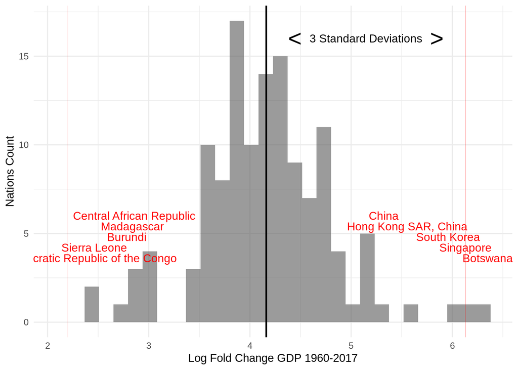

## Increasing GDP is loosely correlated with an aging population

Increasing GDP is correlated with an aging population, but loosely. The primary drivers of this trend are decreased birthrates in high-GDP nations, coupled with longer lifespans. In other words, GDP is not a direct “cause” of an aging population, or at least, is is a few steps upstream of the “causes”.

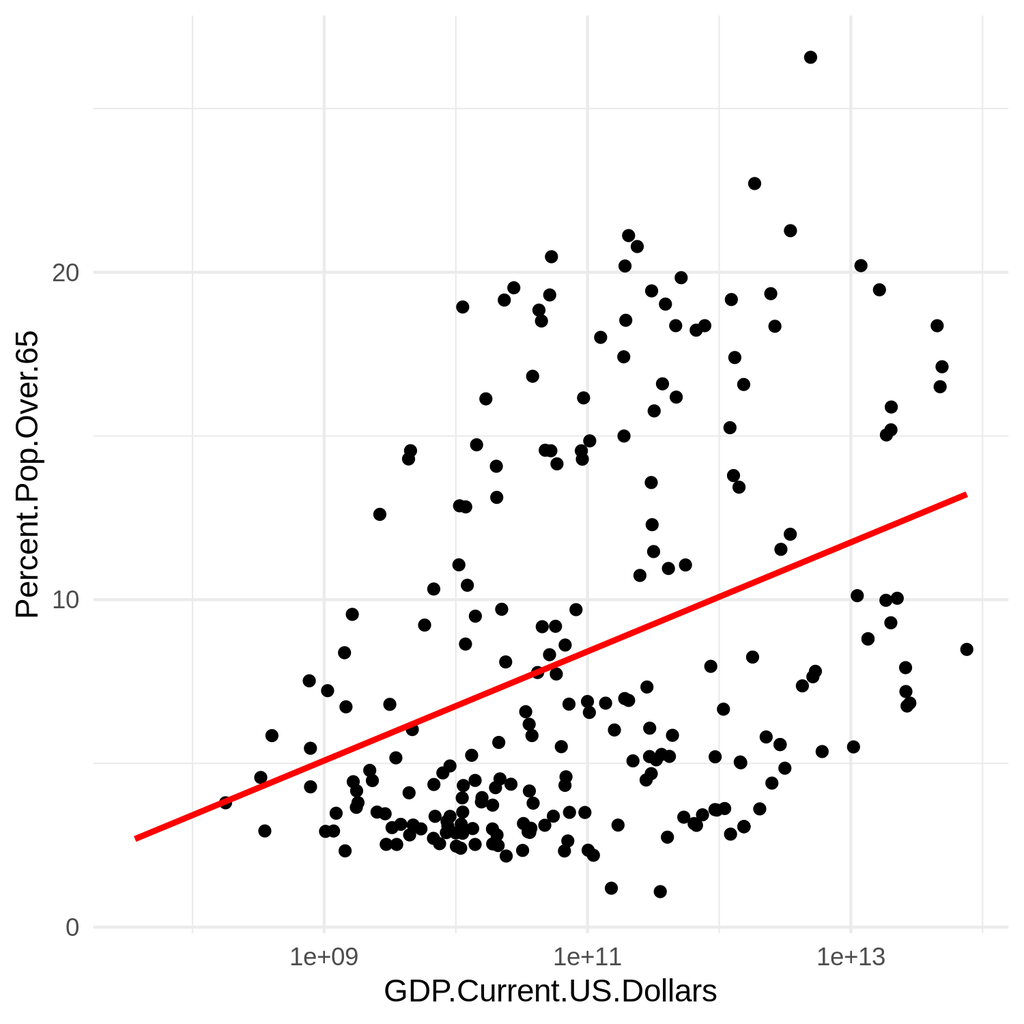

## Reduced birth rate is (not surprisingly) highly correlated with aging population

Birth rates are tightly coupled to the average age of a population. Given that birth rates directly influence the average age of a population, it is not so surprising that the correlation would be so strong. The red line shows the average relationship between national birth rate and the percentage of the population over the age of 65. Each point represents a nation, and the farther away from the red line, the more unusual the relationship between the two variables.

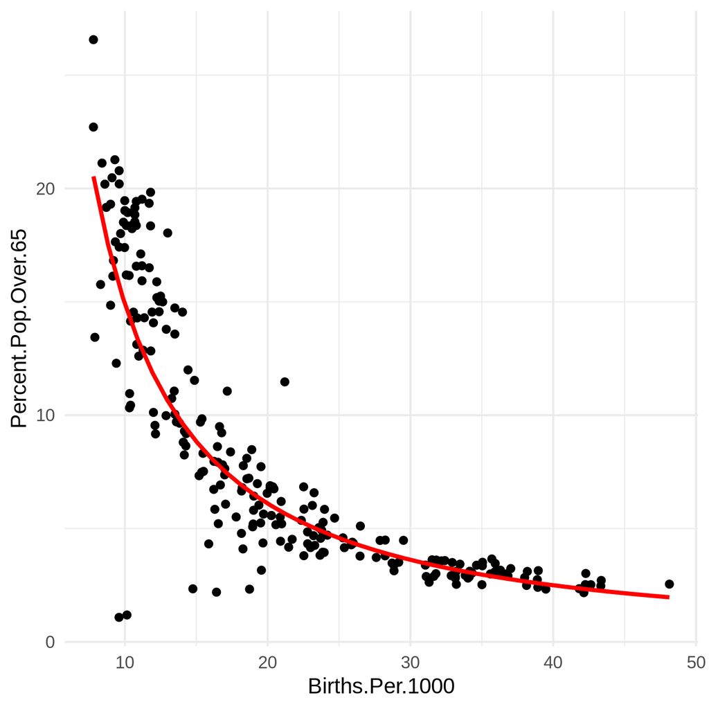

## Some nations have a far younger population than their birth rates would suggest

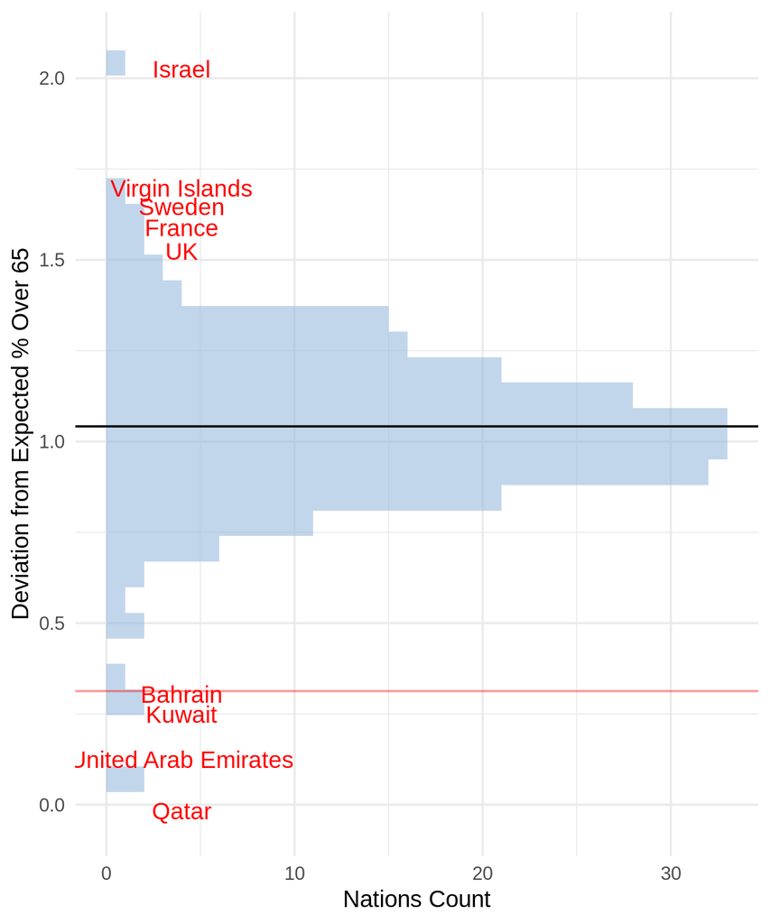

How can these nations have such low birth rates, and yet maintain such a young population? Barring severe humanitarian crises, what other explanation could there be? If we compare the birth rates over time to those of nations with many seniors, the answer becomes clear—The low birth rate is a recent phenominon, and appeared rather suddenly. [Other researchers have noticed this sudden drop in birth rate](https://www.sciencedirect.com/science/article/pii/S1110569017300687), and determined that it is due to families deciding to have fewer children, and space them further apart.

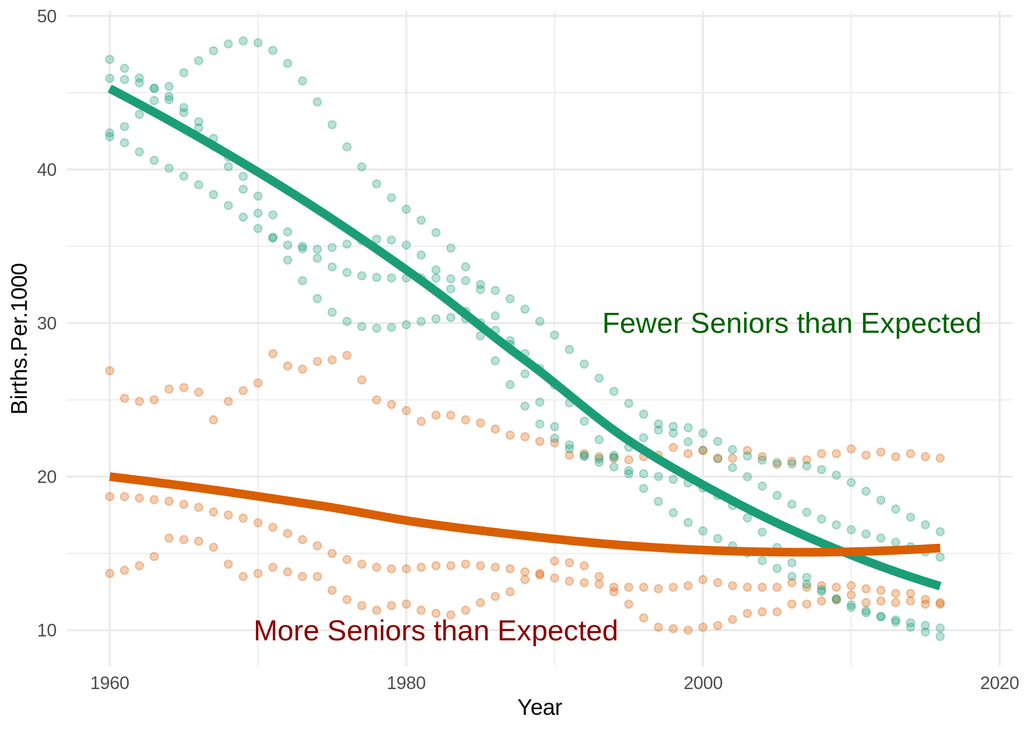

## Map of Notable Nations

[figure not shown]